| title: “Reproducible Research: Peer Assessment 1” |
| --- |
| output: |
| html_document: |
| keep_md: true |

## Loading and preprocessing the data

Unzipping the data and loading csv file

```r
data <- read.table(unz("D:\\Courses\\ReproducibleRsearch\\PeerAssignment1\\RepData_PeerAssessment1\\activity.zip", "activity.csv"), header=T, quote="\"", sep=",")
data$date <- as.Date(data$date)
```

## What is mean total number of steps taken per day?

Creating the dataset by ignoring the missing values

```r
data.ignore.na <- na.omit(data)
daily.steps <- rowsum(data.ignore.na$steps, format(data.ignore.na$date, '%Y-%m-%d'))
daily.steps <- data.frame(daily.steps)
names(daily.steps) <- ("steps")
```

Plotting the graph

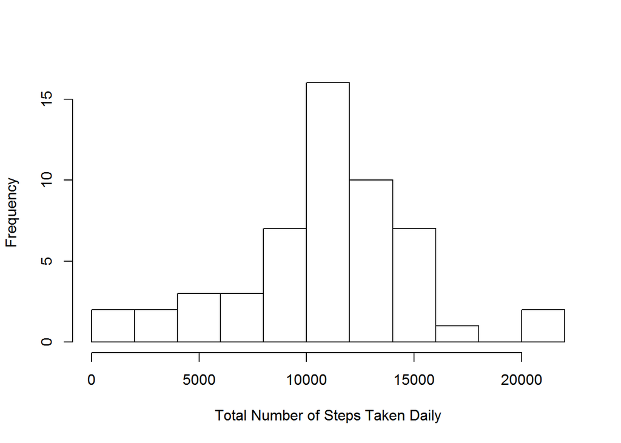

```r
hist(daily.steps$steps, main=" ", breaks=10,
     xlab="Total Number of Steps Taken Daily")
```

Mean and Median calculation

```r
mean(daily.steps$steps)
```

```
## [1] 10766.19
```

```r
median(daily.steps$steps)
```

```
## [1] 10765
```

## What is the average daily activity pattern?

1. Calculate average steps for each of 5-minute interval during a 24-hour period.
2. Make a time series plot (i.e. type = “l”) of the 5-minute interval (x-axis) and the average number of steps taken, averaged across all days (y-axis)
3. Report which 5-minute interval, on average across all the days in the dataset, contains the maximum number of steps?
4. Observer and comment the average daily activity pattern

```r
library(plyr)
interval.mean.steps <- ddply(data.ignore.na,~interval, summarise, mean=mean(steps))
```

Plotting the graph

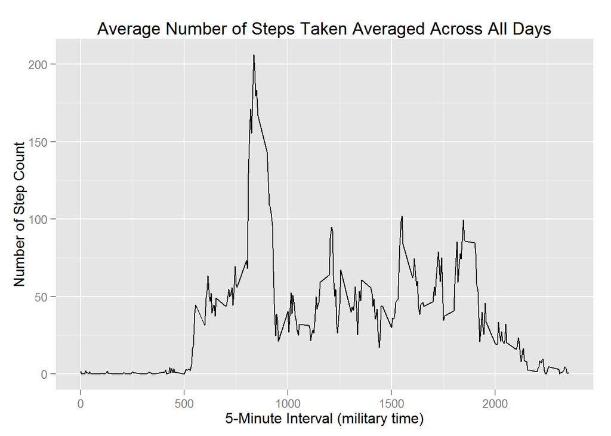

```r
library(ggplot2)
qplot(x=interval, y=mean, data = interval.mean.steps,  geom = "line",
      xlab="5-Minute Interval (military time)",
      ylab="Number of Step Count",
      main="Average Number of Steps Taken Averaged Across All Days"
      )
```

Interval and mean report

```r
interval.mean.steps[which.max(interval.mean.steps$mean), ]
```

```
##     interval     mean
## 104      835 206.1698
```

Obs:# The persons daily activity peak around 8.35am

## Inputting missing values

Calculating and reporting the number of missing values

```r
library(sqldf)
totalNA <- sqldf('
    SELECT d.*
    FROM "data" as d
    WHERE d.steps IS NULL
    ORDER BY d.date, d.interval ')
NROW(totalNA)
```

```
## [1] 2304
```

Filling of missing values

```r
t1 <- sqldf('
    SELECT d.*, i.mean
    FROM "interval.mean.steps" as i
    JOIN "data" as d
    ON d.interval = i.interval
    ORDER BY d.date, d.interval ')

t1$steps[is.na(t1$steps)] <- t1$mean[is.na(t1$steps)]
```

Data preparation to calulate mean and mediation

```r
t1.total.steps <- as.integer( sqldf('
    SELECT sum(steps)
    FROM t1') );

t1.total.steps.by.date <- sqldf('
    SELECT date, sum(steps) as "t1.total.steps.by.date"
    FROM t1 GROUP BY date
    ORDER BY date')

daily.61.steps <- sqldf('
    SELECT date, t1_total_steps_by_date as "steps"
    FROM "t1.total.steps.by.date"
    ORDER BY date')
```

Graph plotting

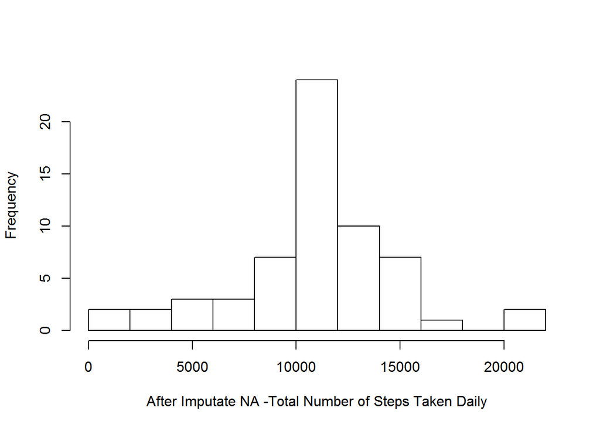

```r
hist(daily.61.steps$steps,
     main=" ",
     breaks=10,
     xlab="After Imputate NA -Total Number of Steps Taken Daily")
```

Mean and mediation calculation and report

```r
t1.mean.steps.per.day <- as.integer(t1.total.steps / NROW(t1.total.steps.by.date) )
t1.mean.steps.per.day
```

```
## [1] 10766
```

```r
t1.median.steps.per.day <- median(t1.total.steps.by.date$t1.total.steps.by.date)
t1.median.steps.per.day
```

```
## [1] 10766.19
```

## Are there differences in activity patterns between weekdays and weekends?

Weekday and Weekends data preparation

```r
t1$weektime <- as.factor(ifelse(weekdays(t1$date) %in%
                c("Saturday","Sunday"),"weekend", "weekday"))

t5 <- sqldf('
    SELECT interval, avg(steps) as "mean.steps", weektime
    FROM t1
    GROUP BY weektime, interval
    ORDER BY interval ')
```

Plotting the graph

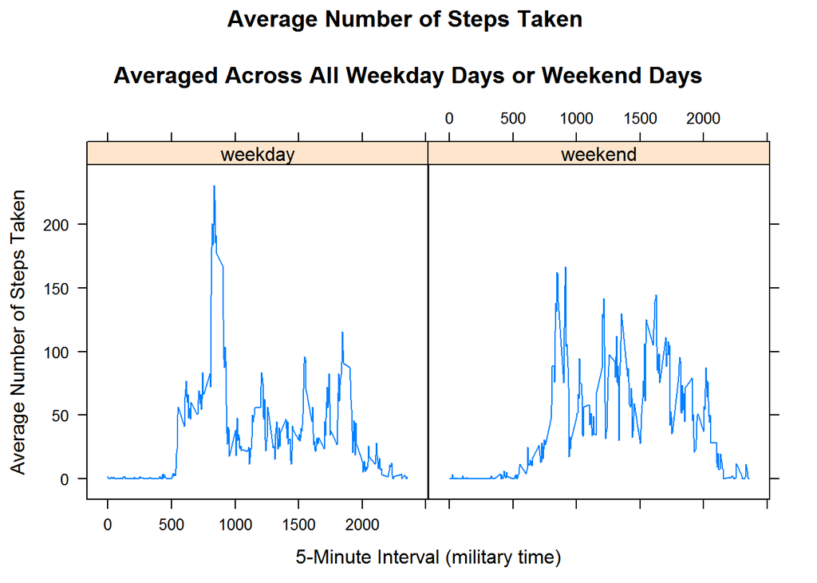

```r
library("lattice")
p <- xyplot(mean.steps ~ interval | factor(weektime), data=t5,
       type = 'l',
       main="Average Number of Steps Taken
       \nAveraged Across All Weekday Days or Weekend Days",
       xlab="5-Minute Interval (military time)",
       ylab="Average Number of Steps Taken")
print (p)
```

Obs:# Yes. The plot indicates that the person moves around more during the weekend days.